# RobotGoWest : Vers une interprétation des signaux électrophysiologiques végétaux par intelligence artificielle

## Introduction

Le projet **RobotGoWest** ambitionne de concevoir un robot mobile capable de s’orienter vers la lumière solaire en s’inspirant des mécanismes biologiques des plantes. L’objectif central de cette étude est de développer un réseau de neurones capable de décoder les signaux électrophysiologiques émis par une *Monstera deliciosa* pour distinguer avec précision les périodes d’ensoleillement de celles d’obscurité. En tant que preuve de concept, ce travail vise à valider la faisabilité d’un pipeline d’analyse de données brutes issues de capteurs végétaux et à démontrer que ces signaux contiennent une information exploitable pour classifier l’état lumineux de la plante.

## Acquisition et prétraitement des signaux

### Protocole expérimental et collecte de données

| Capteur | Position sur la plante | Type d’organe |
| --- | --- | --- |
| 1 | Tige | Aérien |
| 2 | Racine (Sol) | Souterrain |
| 3 | Tige | Aérien |
| 4 | Pétiole | Aérien |
| 5 | Pétiole | Aérien |
| 6 | Tige | Aérien |
| 7 | Pétiole | Aérien |
| 8 | Racine (Sol) | Souterrain |

*Tableau 1 : Positionnement des capteurs sur la plante*

Les données brutes, numérisées avec une fréquence d’échantillonnage de 250 Hz, ont été segmentées en échantillons de 512 points (environ 2 secondes), labellisés manuellement selon les heures de lever et de coucher du soleil. Après nettoyage, le jeu de données final comprend près de 290 000 échantillons, stockés sous forme de tableaux numpy de dimensions $[1, 8, n]$.

### Filtrage et nettoyage du signal

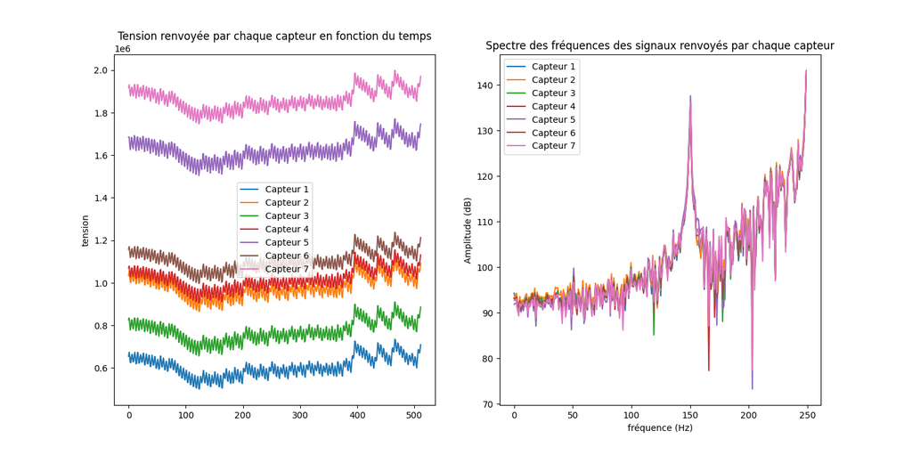

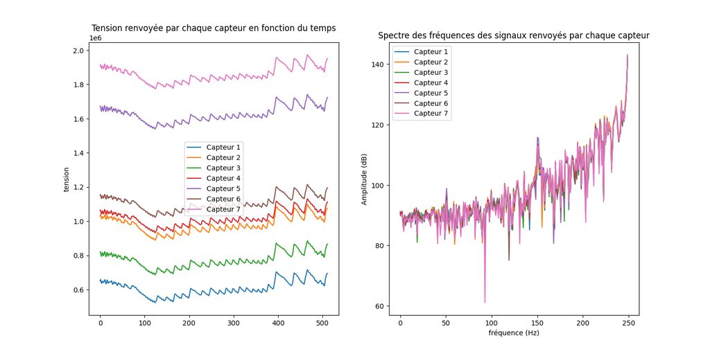

*Fig 1: Échantillon brute de jour (en haut) et après filtration à 50Hz (Q = 30.0) (en bas)*

## Analyse statistique et exploration des données

### Validation des différences interclasses

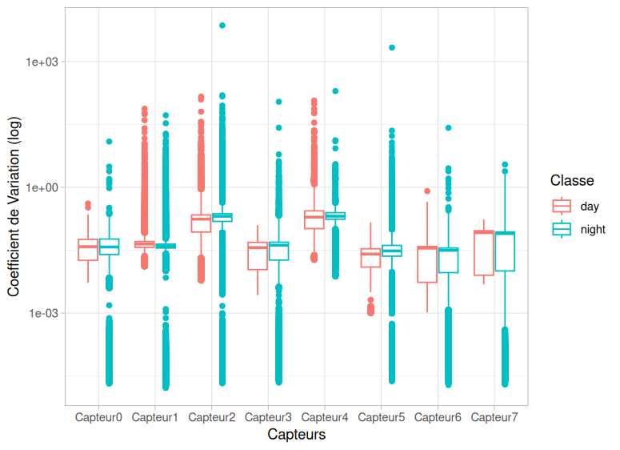

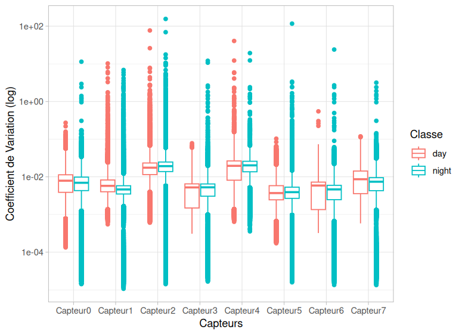

*Fig 2: Évolution du coefficient de variation des échantillons entre le jour et la nuit et par capteur. En haut avant filtration, en bas après filtration des 50 Hz (Q=1.0)*

### Visualisation par UMAP

Pour explorer la structure des données sans les réduire excessivement, une projection UMAP (Uniform Manifold Approximation and Projection) a été réalisée sur les vecteurs de dimension 512 et sur leurs transformées de Fourier rapides (FFT). Les résultats initiaux sur les données brutes n’ont montré aucune séparation claire entre les classes. Cependant, après normalisation par le capteur 8 et filtrage, une meilleure séparation des clusters est observable, bien qu’un chevauchement important persiste.

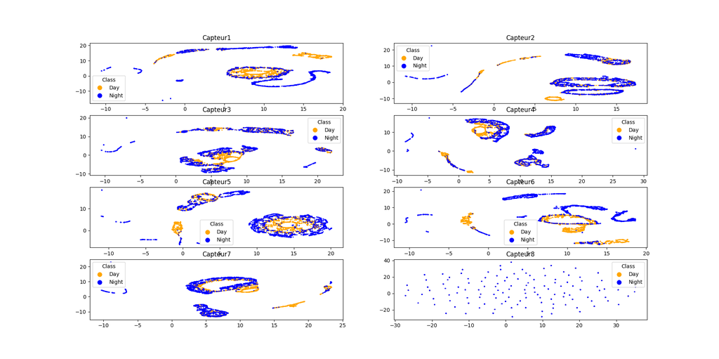

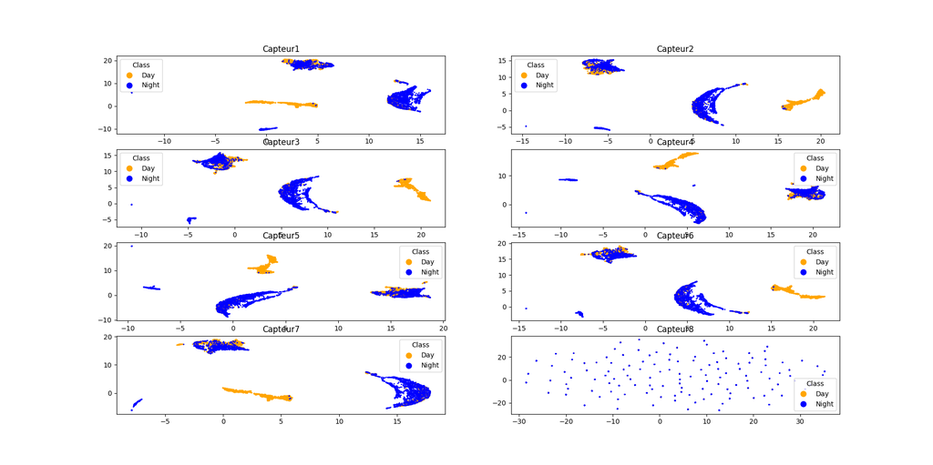

*Fig 3: Projection UMAP sur 3000 échantillons (en haut) et sur la FFT (en bas) normalisé par le capteur 8.*

## Modélisation par réseau de neurones

Pour classifier ces signaux, nous avons implémenté un réseau de neurones convolutifs compact (CNN), inspiré de l’architecture EEGNet proposée par Lawhern et al. en 2018. Ce modèle a été adapté aux spécificités de nos données : 8 canaux d’électrodes et une longueur de signal de 512 échantillons.

L’architecture comprend une couche de convolution 2D pour l’extraction de caractéristiques temporelles, suivie d’une convolution par profondeur pour capturer les relations spatiales entre les électrodes. Des couches de normalisation par lot (Batch Normalization) et de régularisation (Dropout) ont été intégrées pour stabiliser l’apprentissage et prévenir le surapprentissage. Le réseau se termine par une couche dense et une fonction d’activation sigmoïde pour la classification binaire (jour/nuit).

```python
import torch
import torchvision
import torch.nn as nn
import torch.optim as optim
from torch.utils.data import DataLoader, TensorDataset
from torchmetrics import Accuracy

### SET MODEL SPECIFICATIONS ###
fs= 250                  #sampling frequency
channel= 8               #number of electrode
num_input= 1             #number of channel picture (for EEG signal is always : 1)
num_class= 2             #number of classes
signal_length = 512      #number of sample in each tarial
F1= 8                    #number of temporal filters
D= 3                     #depth multiplier (number of spatial filters)
F2= D*F1                 #number of pointwise filters
kernel_size_1= (1,round(fs/2))
kernel_size_2= (channel, 1)
kernel_size_3= (1, round(fs/8))
kernel_size_4= (1, 1)
kernel_avgpool_1= (1,4)
kernel_avgpool_2= (1,8)
dropout_rate= 0.5
ks0= int(round((kernel_size_1[0]-1)/2))
ks1= int(round((kernel_size_1[1]-1)/2))
kernel_padding_1= (ks0, ks1-1)
ks0= int(round((kernel_size_3[0]-1)/2))
ks1= int(round((kernel_size_3[1]-1)/2))
kernel_padding_3= (ks0, ks1)

### DESIGN MODEL ###
class EEGNet(nn.Module):
    def __init__(self):
        super().__init__()
        # layer 1
        self.conv2d = nn.Conv2d(num_input, F1, kernel_size_1, padding=kernel_padding_1)
        self.Batch_normalization_1 = nn.BatchNorm2d(F1)
        # layer 2
        self.Depthwise_conv2D = nn.Conv2d(F1, D*F1, kernel_size_2, groups= F1)
        self.Batch_normalization_2 = nn.BatchNorm2d(D*F1)
        self.Elu = nn.ELU()
        self.Average_pooling2D_1 = nn.AvgPool2d(kernel_avgpool_1)
        self.Dropout = nn.Dropout2d(dropout_rate)
        # layer 3
        self.Separable_conv2D_depth = nn.Conv2d( D*F1, D*F1, kernel_size_3, padding=kernel_padding_3, groups= D*F1)
        self.Separable_conv2D_point = nn.Conv2d(D*F1, F2, kernel_size_4)
        self.Batch_normalization_3 = nn.BatchNorm2d(F2)
        self.Average_pooling2D_2 = nn.AvgPool2d(kernel_avgpool_2)
        # layer 4
        self.Flatten = nn.Flatten()
        self.Dense = nn.Linear(F2*round(signal_length/34), num_class)
        self.Sigmoid = nn.Sigmoid()

    def forward(self, x):
        # layer 1
        y = self.Batch_normalization_1(self.conv2d(x))
        # layer 2
        y = self.Batch_normalization_2(self.Depthwise_conv2D(y))
        y = self.Elu(y)
        y = self.Dropout(self.Average_pooling2D_1(y))
        # layer 3
        y = self.Separable_conv2D_depth(y)
        y = self.Batch_normalization_3(self.Separable_conv2D_point(y))
        y = self.Elu(y)
        y = self.Dropout(self.Average_pooling2D_2(y))
        # layer 4
        y = self.Flatten(y)
        y = self.Dense(y)
        y = self.Sigmoid(y)

        return y
```

Bien que le pipeline soit opérationnel et que les visualisations UMAP suggèrent une séparation des classes, l’entraînement complet du modèle et l’évaluation de sa précision finale sont en cours. Les résultats préliminaires sur la qualité des données filtrées et normalisées sont encourageants pour la suite du projet.

## Conclusion

Ce projet de preuve de concept a permis de valider la faisabilité technique de l’extraction et du prétraitement de signaux électrophysiologiques végétaux. Nous avons démontré que, malgré le bruit ambiant et les artefacts expérimentaux, il est possible d’isoler des variations périodiques liées au cycle jour/nuit de la *Monstera deliciosa*. L’analyse statistique et la visualisation par UMAP confirment la présence d’une structure exploitable dans les données, notamment après normalisation par les capteurs de sol.

Le projet RobotGoWest reste en cours. Les prochaines étapes consisteront à finaliser l’entraînement du réseau de neurones sur le jeu de données nettoyé, à évaluer rigoureusement ses performances de classification et à envisager l’intégration de ce module de détection dans le système de contrôle du robot. La robustesse de cette approche face à des conditions environnementales variables et sur le long terme constitue le défi majeur à relever pour transformer cette preuve de concept en une technologie fonctionnelle.